# GPU Price and Performance Analysis

# D. Predictive Modeling

Here, we build linear regression models to predict GPU price and performance based on technical specifications. We use the caret and car packages for model training, validation, and diagnostics.

### Predicting GPU Price (Release_Price)

We first filter the data to include only observations with price information. We then split the data into training and validation sets, fit a linear model, and evaluate its performance using MAE and RMSE.

```r
library(caret)
library(car)
library(MASS)
library(dplyr)

# Filter data and handle outliers
data_price <- data_combined %>%
  filter(!is.na(Release_Price))

data_price_clean <- data_price %>%
  filter(Release_Price != 14999)

# Split data
set.seed(2025)
train_index <- createDataPartition(data_price_clean$Release_Price, p = 0.8, list = FALSE)
train_data <- data_price_clean[train_index, ]
valid_data <- data_price_clean[-train_index, ]

# Fit the full linear model
full_formula <- Release_Price ~ Dedicated + Direct_X + Integrated +
  L2_Cache + Max_Power + Memory + Memory_Bus + Memory_Type +
  Notebook_GPU + Open_GL + PSU_Watt + PSU_Amps + Power_Connector +
  Process + SLI_Crossfire + Pixel_Level_Best + Pixel_Level +
  Has_HDMI + Has_DVI + Has_VGA

train_data_clean <- na.omit(train_data)
train_data_clean <- droplevels(train_data_clean)

drop_vars <- names(train_data_clean)[sapply(train_data_clean, function(x) is.factor(x) && nlevels(x) < 2)]
formula_vars <- setdiff(all.vars(full_formula), drop_vars)
clean_formula <- as.formula(paste("Release_Price ~", paste(formula_vars[-1], collapse = " + ")))

full_model <- lm(clean_formula, data = train_data_clean)
summary(full_model)
```

```
##
## Call:
## lm(formula = clean_formula, data = train_data_clean)
##
## Residuals:
##      Min       1Q   Median       3Q      Max
## -152.497  -29.285   -4.053   26.121  209.579
##
## Coefficients:
##                                       Estimate Std. Error t value Pr(>|t|)
## (Intercept)                         -2.110e+04  3.623e+03  -5.824 3.72e-08 ***
## Direct_X                             1.337e+03  2.436e+02   5.488 1.83e-07 ***
## L2_Cache                            -2.767e-02  1.696e-02  -1.632 0.104923
## Max_Power                            2.112e+00  2.087e-01  10.118  < 2e-16 ***
## Memory                               1.005e-03  5.266e-03   0.191 0.848935
## Memory_Bus                           6.234e-01  1.484e-01   4.202 4.66e-05 ***
## Memory_TypeGDDR5X                    1.540e+02  2.533e+01   6.081 1.06e-08 ***
## Open_GL                              1.112e+03  4.143e+02   2.684 0.008135 **
## PSU_Watt                            -3.283e-01  2.381e-01  -1.379 0.170095
## PSU_Amps                             1.093e+01  3.066e+00   3.563 0.000501 ***
## Power_Connector1x 6-pin + 1x 8-pin  -4.943e+01  2.790e+01  -1.771 0.078644 .
## Power_Connector1x 8-pin              9.681e+00  1.524e+01   0.635 0.526303
## Power_Connector2x 6-pin             -4.873e+00  3.061e+01  -0.159 0.873735
## Power_Connector2x 8-pin             -3.762e+01  3.404e+01  -1.105 0.271004
## Power_Connector4x 6-pin              5.696e+01  8.100e+01   0.703 0.483055
## Power_ConnectorNone                 -7.838e+01  2.335e+01  -3.357 0.001014 **
## Process                             -3.613e+00  2.413e+00  -1.497 0.136511
## SLI_CrossfireYes                     4.558e+00  1.812e+01   0.252 0.801756
## Pixel_Level_BestMedium              -2.296e+01  3.762e+01  -0.610 0.542657
## Pixel_Level_BestMedium-Low          -1.307e+01  5.285e+01  -0.247 0.805034
## Pixel_LevelMedium                   -1.710e+02  4.058e+01  -4.213 4.47e-05 ***
## Pixel_LevelMedium-Low               -6.594e+01  8.969e+01  -0.735 0.463480
## Pixel_LevelVery High                -1.465e+02  4.003e+01  -3.660 0.000356 ***
## Has_HDMI1                           -1.258e+02  9.840e+01  -1.279 0.203141
## Has_DVI1                             7.892e+01  2.053e+01   3.844 0.000183 ***
## ---
## Signif. codes:  0 '***' 0.001 '**' 0.01 '*' 0.05 '.' 0.1 ' ' 1
##
## Residual standard error: 62.81 on 141 degrees of freedom
## Multiple R-squared:  0.9464, Adjusted R-squared:  0.9373
## F-statistic: 103.7 on 24 and 141 DF,  p-value: < 2.2e-16
```

```r
# Model selection using AIC and BIC
step_aic <- stepAIC(full_model, direction = "both", trace = FALSE)
n <- nrow(train_data_clean)
step_bic <- stepAIC(full_model, direction = "both", k = log(n), trace = FALSE)

# Evaluation
valid_data_clean <- droplevels(valid_data)
factor_vars <- names(train_data_clean)[sapply(train_data_clean, is.factor)]
for(fv in factor_vars){
  valid_data_clean[[fv]] <- factor(valid_data_clean[[fv]], levels = levels(train_data_clean[[fv]]))
}

pred_aic <- predict(step_aic, newdata = valid_data_clean)
pred_bic <- predict(step_bic, newdata = valid_data_clean)

MAE_aic <- mean(abs(pred_aic - valid_data_clean$Release_Price), na.rm=TRUE)
RMSE_aic <- sqrt(mean((pred_aic - valid_data_clean$Release_Price)^2, na.rm=TRUE))

MAE_bic <- mean(abs(pred_bic - valid_data_clean$Release_Price), na.rm=TRUE)
RMSE_bic <- sqrt(mean((pred_bic - valid_data_clean$Release_Price)^2, na.rm=TRUE))

results <- data.frame(
  Model = c("AIC", "BIC"),
  MAE = c(MAE_aic, MAE_bic),
  RMSE = c(RMSE_aic, RMSE_bic)
)
print(results)
```

```
##   Model       MAE     RMSE
## 1   AIC 106.79034 200.3974
## 2   BIC  94.31905 169.5958
```

### Predicting GPU Performance (Pixel_Rate)

Similar to the price prediction, we build and evaluate a linear model to predict GPU performance based on the technical specifications.

```r
# Filter data and handle outliers
data_perf <- data_combined %>%
  filter(!is.na(Pixel_Rate))

upper_limit <- mean(data_perf$Pixel_Rate) + 2*sd(data_perf$Pixel_Rate, na.rm=TRUE)
data_perf_clean <- data_perf %>% filter(Pixel_Rate <= upper_limit)

# Split data
set.seed(2025)
train_index <- createDataPartition(data_perf_clean$Pixel_Rate, p = 0.8, list = FALSE)
train_data <- data_perf_clean[train_index, ]
valid_data <- data_perf_clean[-train_index, ]

# Fit the full linear model
full_formula_perf <- Pixel_Rate ~ Dedicated + Direct_X + Integrated +
  L2_Cache + Max_Power + Memory + Memory_Bus + Memory_Type +
  Notebook_GPU + Open_GL + PSU_Watt + PSU_Amps + Power_Connector +
  Process + SLI_Crossfire + Pixel_Level_Best + Pixel_Level +
  Has_HDMI + Has_DVI + Has_VGA

train_data_clean <- na.omit(train_data)
train_data_clean <- droplevels(train_data_clean)

drop_vars <- names(train_data_clean)[sapply(train_data_clean, function(x) is.factor(x) && nlevels(x) < 2)]
formula_vars <- setdiff(all.vars(full_formula_perf), drop_vars)
clean_formula_perf <- as.formula(paste("Pixel_Rate ~", paste(formula_vars[-1], collapse = " + ")))

full_model_perf <- lm(clean_formula_perf, data = train_data_clean)
summary(full_model_perf)
```

```
##
## Call:
## lm(formula = clean_formula_perf, data = train_data_clean)
##
## Residuals:
##     Min      1Q  Median      3Q     Max
## -12.051  -3.609  -0.963   1.548  37.265
##
## Coefficients: (1 not defined because of singularities)
##                                       Estimate Std. Error t value Pr(>|t|)
## (Intercept)                         -4.429e+03  5.035e+02  -8.795 6.68e-14 ***
## Direct_X                             4.004e+02  3.192e+01  12.542  < 2e-16 ***
## L2_Cache                             1.106e-02  3.122e-03   3.542 0.000620 ***
## Max_Power                            1.008e-01  5.721e-02   1.763 0.081233 .
## Memory                               7.667e-04  7.275e-04   1.054 0.294627
## Memory_Bus                           5.347e-02  4.556e-02   1.174 0.243480
## Open_GL                             -7.460e+01  5.583e+01  -1.336 0.184763
## PSU_Watt                            -5.241e-02  3.940e-02  -1.330 0.186697
## PSU_Amps                            -3.353e-01  4.165e-01  -0.805 0.422888
## Power_Connector1x 6-pin + 1x 8-pin   1.683e+01  7.942e+00   2.119 0.036738 *
## Power_Connector1x 8-pin             -3.638e+00  2.030e+00  -1.792 0.076313 .
## Power_Connector2x 6-pin              1.424e+01  4.155e+00   3.427 0.000907 ***
## Power_Connector2x 8-pin              3.217e+01  1.139e+01   2.825 0.005769 **
## Power_Connector4x 6-pin              5.326e+00  1.257e+01   0.424 0.672800
## Power_ConnectorNone                 -1.183e+01  2.991e+00  -3.956 0.000148 ***
## Process                             -1.026e+00  2.804e-01  -3.659 0.000418 ***
## SLI_CrossfireYes                    -1.483e+00  2.962e+00  -0.501 0.617659
## Pixel_Level_BestMedium-Low          -4.746e+00  3.472e+00  -1.367 0.174949
## Pixel_LevelMedium                    5.135e+00  4.726e+00   1.087 0.279988
## Pixel_LevelVery High                -3.568e+00  4.650e+00  -0.767 0.444790
## Has_HDMI1                                   NA         NA      NA       NA
## Has_DVI1                             8.738e-01  2.499e+00   0.350 0.727373
## ---
## Signif. codes:  0 '***' 0.001 '**' 0.01 '*' 0.05 '.' 0.1 ' ' 1
##
## Residual standard error: 7.085 on 94 degrees of freedom
## Multiple R-squared:  0.9075, Adjusted R-squared:  0.8878
## F-statistic: 46.11 on 20 and 94 DF,  p-value: < 2.2e-16
```

```r
# Model selection
step_aic_perf <- stepAIC(full_model_perf, direction = "both", trace = FALSE)
n <- nrow(train_data_clean)
step_bic_perf <- stepAIC(full_model_perf, direction = "both", k = log(n), trace = FALSE)

# Evaluation
valid_data_clean <- droplevels(valid_data)
factor_vars <- names(train_data_clean)[sapply(train_data_clean, is.factor)]
for(fv in factor_vars){
  valid_data_clean[[fv]] <- factor(valid_data_clean[[fv]], levels = levels(train_data_clean[[fv]]))
}

pred_aic <- predict(step_aic_perf, newdata = valid_data_clean)
pred_bic <- predict(step_bic_perf, newdata = valid_data_clean)

MAE_aic <- mean(abs(pred_aic - valid_data_clean$Pixel_Rate), na.rm = TRUE)
RMSE_aic <- sqrt(mean((pred_aic - valid_data_clean$Pixel_Rate)^2, na.rm = TRUE))

MAE_bic <- mean(abs(pred_bic - valid_data_clean$Pixel_Rate), na.rm = TRUE)
RMSE_bic <- sqrt(mean((pred_bic - valid_data_clean$Pixel_Rate)^2, na.rm = TRUE))

results_perf <- data.frame(
  Model = c("AIC", "BIC"),
  MAE = c(MAE_aic, MAE_bic),
  RMSE = c(RMSE_aic, RMSE_bic)
)
print(results_perf)
```

```
##   Model      MAE     RMSE
## 1   AIC 22.18747 48.77928
## 2   BIC 24.46313 54.22763
```

# E. Final Analysis and Conclusions

This final section explores the performance-to-price ratio over time and identifies which manufacturers stand out in specific price and performance segments.

### Performance-to-Price Ratio Over Time

We compute and visualize the average performance-to-price ratio over time to see if GPUs are becoming more cost-effective.

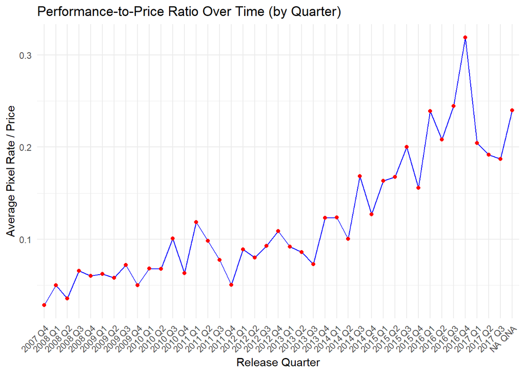

```r
# Calculate Performance-to-Price Ratio
data_price <- data_combined %>%
  filter(!is.na(Release_Price) & !is.na(Pixel_Rate)) %>%
  mutate(Perf_Price_Ratio = Pixel_Rate / Release_Price)

# Summarize by quarter
perf_price_qtr <- data_price %>%
  group_by(Release_Quarter) %>%
  summarise(Avg_Ratio = mean(Perf_Price_Ratio, na.rm = TRUE)) %>%
  arrange(Release_Quarter)

# Plot the trend
ggplot(perf_price_qtr, aes(x = Release_Quarter, y = Avg_Ratio, group = 1)) +
  geom_line(color = "blue") +
  geom_point(color = "red") +
  labs(title = "Performance-to-Price Ratio Over Time (by Quarter)",
       x = "Release Quarter", y = "Average Pixel Rate / Price") +
  theme_minimal() +
  theme(axis.text.x = element_text(angle = 45, hjust = 1))
```

```r
# ANOVA to test for significant differences across quarters
anova_full_qtr <- aov(Perf_Price_Ratio ~ Release_Quarter, data = data_price)
summary(anova_full_qtr)
```

```
##                  Df Sum Sq Mean Sq F value Pr(>F)
## Release_Quarter  40  2.158 0.05394      18 <2e-16 ***
## Residuals       515  1.543 0.00300
## ---
## Signif. codes:  0 '***' 0.001 '**' 0.01 '*' 0.05 '.' 0.1 ' ' 1
```

### Manufacturer Standouts

We analyze the price and performance distributions by manufacturer to identify which companies excel in certain market segments.

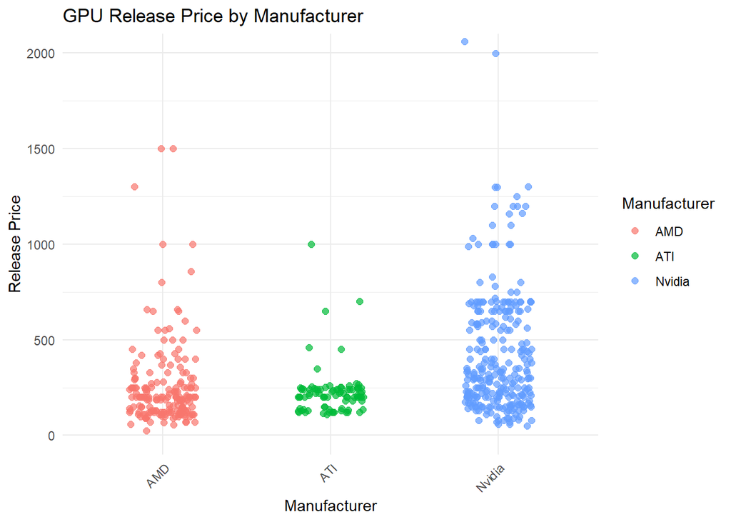

```r
# Price Segment Analysis
manufacturer_summary <- data_price %>%
  group_by(Manufacturer) %>%
  summarise(
    Avg_Price = mean(Release_Price, na.rm = TRUE),
    Count = n(),
    .groups = "drop"
  ) %>%
  arrange(desc(Avg_Price))

ggplot(data_price, aes(x = Manufacturer, y = Release_Price)) +
  geom_jitter(aes(color = Manufacturer), width = 0.2, alpha = 0.7, size = 2) +
  labs(title = "GPU Release Price by Manufacturer",
       x = "Manufacturer",
       y = "Release Price") +
  coord_cartesian(ylim = c(0, 2000)) +
  theme_minimal() +
  theme(axis.text.x = element_text(angle = 45, hjust = 1))
```

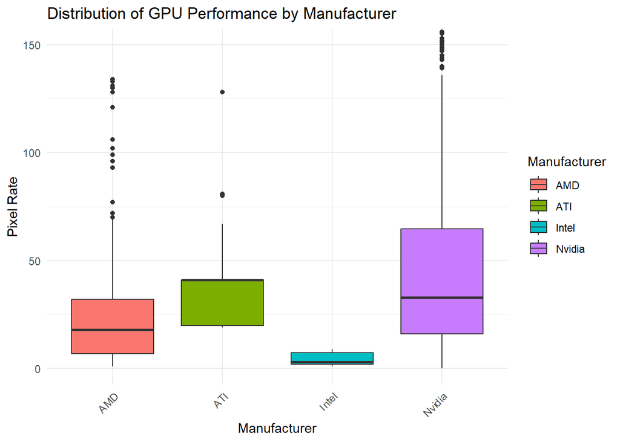

```r
# Performance Segment Analysis
manufacturer_perf_summary <- data_combined %>%
  filter(!is.na(Pixel_Rate)) %>%
  group_by(Manufacturer) %>%
  summarise(
    Avg_Performance = mean(Pixel_Rate, na.rm = TRUE),
    Count = n(),
    .groups = "drop"
  ) %>%
  arrange(desc(Avg_Performance))

ggplot(data_combined %>% filter(!is.na(Pixel_Rate)), aes(x = Manufacturer, y = Pixel_Rate, fill = Manufacturer)) +
  geom_boxplot() +
  labs(title = "Distribution of GPU Performance by Manufacturer",
       x = "Manufacturer",
       y = "Pixel Rate") +
  coord_cartesian(ylim = c(0, 150)) +
  theme_minimal() +
  theme(axis.text.x = element_text(angle = 45, hjust = 1))
```